# Análise de Componentes Principais (ACP)

11 dezembro 2025

```r
library(ISLR2)
library(mlbench)
library(pls)
library(ggplot2)
library(dplyr)
library(tibble)
```

# Exercício 1 — NCI60 (expressão génica; p ≈ 6.830)

**Dados**: `ISLR2::NCI60` (64 linhas = linhas celulares; ~6.830 genes como variáveis).

1. Use a library `ISLR2` e obtenha a matriz `NCI60$data`. Quantas variáveis (genes) existem? Há valores em falta?

```r
X_raw <- NCI60$data
labs <- NCI60$labs
n <- nrow(X_raw); p <- ncol(X_raw)

na_total <- sum(is.na(X_raw))
list(n_obs = n, p_variaveis = p, faltantes_total = na_total)
```

```
## $n_obs
## [1] 64
##
## $p_variaveis
## [1] 6830
##
## $faltantes_total
## [1] 0
```

2. Construa `X <- scale(NCI60$data)` (centrar e padronizar por coluna). Justifique a escolha de **correlações** em vez de **covariâncias** neste contexto.

```r
X <- scale(NCI60$data)

summ <- as_tibble(X) %>%
  summarise(across(everything(), list(media = ~mean(.x), sd = ~sd(.x))))
```

> A escolha de usar a matriz de correlação (ou seja, `scale=TRUE` / padronização) em vez da matriz de covariância é fundamental quando as variáveis originais têm escalas ou variâncias muito díspares.
3. Aplique `prcomp` a `X` (não volte a padronizar dentro de `prcomp`). Extraia **valores próprios**, **PVE** e **PVE acumulada**. Faça o **scree plot** e o gráfico da PVE acumulada.

```r
pc_nci <- prcomp(X, center = FALSE, scale = FALSE)

ev <- pc_nci$sdev^2
pve <- ev / sum(ev)
cpve <- cumsum(pve)

resumo_pve <- tibble(
  CP = seq_along(ev),
  autovalor = ev,
  PVE = pve,
  PVE_acumulada = cpve
) %>%
  slice(1:15)

resumo_pve
```

```
## # A tibble: 15 × 4
##       CP autovalor    PVE PVE_acumulada
##    <int>     <dbl>  <dbl>         <dbl>
##  1     1      776. 0.114          0.114
##  2     2      461. 0.0676         0.181
##  3     3      393. 0.0575         0.239
##  4     4      290. 0.0425         0.281
##  5     5      255. 0.0373         0.318
##  6     6      247. 0.0362         0.355
##  7     7      209. 0.0307         0.385
##  8     8      183. 0.0269         0.412
##  9     9      173. 0.0253         0.437
## 10    10      162. 0.0238         0.461
## 11    11      161. 0.0236         0.485
## 12    12      148. 0.0216         0.506
## 13    13      140. 0.0205         0.527
## 14    14      135. 0.0198         0.547
## 15    15      131. 0.0192         0.566
```

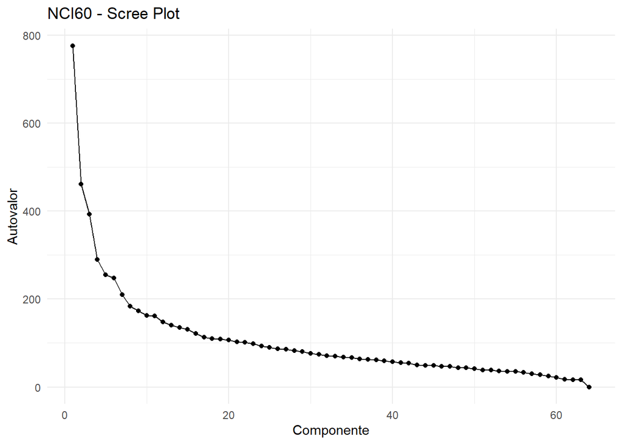

```r
qplot(y = ev, x = seq_along(ev), geom = c("line", "point")) +
  labs(x = "Componente", y = "Autovalor", title = "NCI60 - Scree Plot") +
  theme_minimal()
```

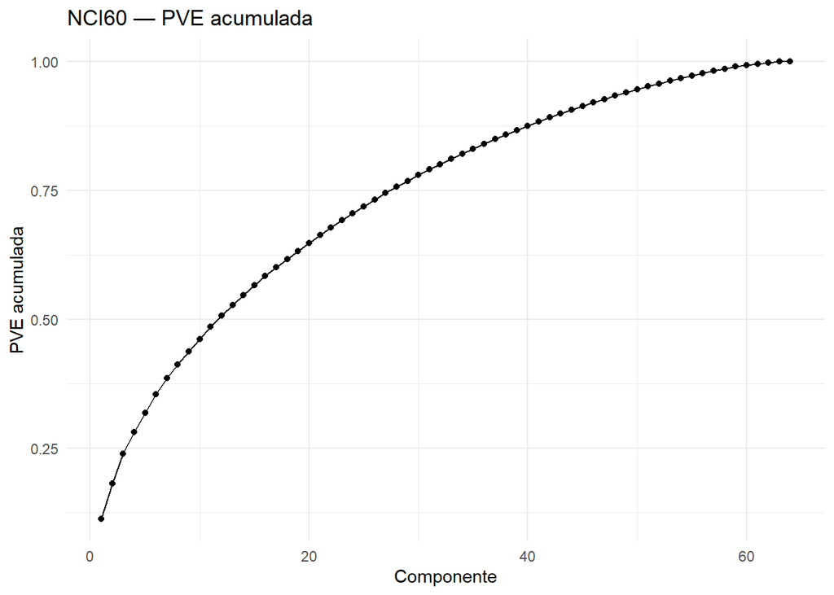

```r
qplot(y = cpve, x = seq_along(cpve), geom = c("line","point")) +
  labs(x = "Componente", y = "PVE acumulada", title = "NCI60 — PVE acumulada") +
  theme_minimal()
```

4. Faça um gráfico **CP1 vs CP2** dos *scores*. Use `NCI60$labs` apenas para **colorir** os pontos por tipo de cancro (não entra na ACP). Comente padrões/separações.

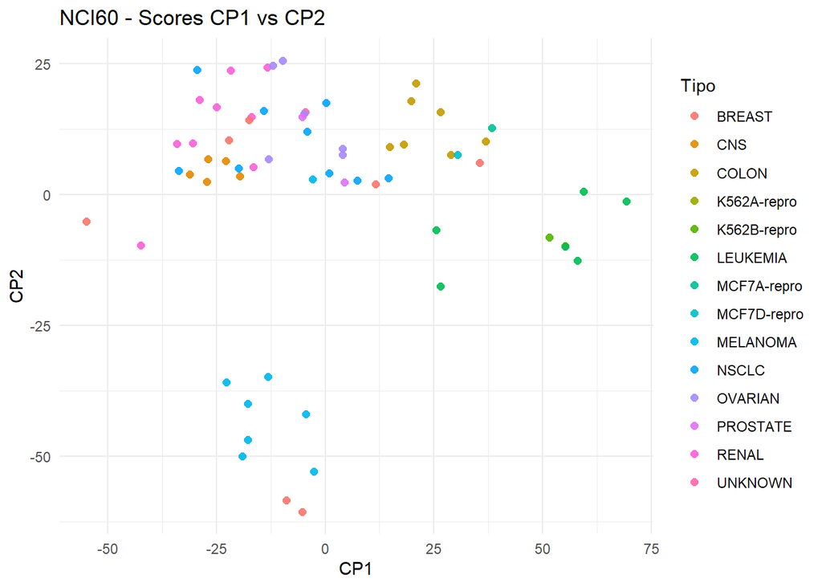

```r
Scores <- as_tibble(pc_nci$x[,1:2], .name_repair = "minimal") %>%
  mutate(tipo = labs)

colnames(Scores)[1:2] <- c("CP1","CP2")

Scores$tipo <- factor(Scores$tipo)

ggplot(Scores, aes(x = CP1, y = CP2, color = tipo)) +
  geom_point(size = 2, alpha = 0.9) +
  labs(title = "NCI60 - Scores CP1 vs CP2", color = "Tipo") +
  theme_minimal()
```

> A projeção das amostras no plano definido pelas duas primeiras componentes principais (CP1 e CP2) revela a estrutura de clusterização biológica dos dados.
5. Identifique os **25 genes** com maiores |loadings| em **CP1** e em **CP2** (duas listas). Discuta se há sobreposição entre as listas.

```r
load <- pc_nci$rotation
ord1 <- order(abs(load[,1]), decreasing = TRUE)[1:25]
ord2 <- order(abs(load[,2]), decreasing = TRUE)[1:25]
Top_CP1 <- tibble(
  gene = colnames(X_raw)[ord1],
  loading = load[ord1,1]
)
Top_CP2 <- tibble(
  gene = colnames(X_raw)[ord2],
  loading = load[ord2,2]
)
list(Top25_CP1 = Top_CP1,
     Top25_CP2 = Top_CP2,
     sobreposicao = length(interaction(Top_CP1$gene, Top_CP2$gene))
)
```

```
## $Top25_CP1
## # A tibble: 25 × 2
##    gene  loading
##    <chr>   <dbl>
##  1 5951  -0.0311
##  2 5874  -0.0304
##  3 5886  -0.0300
##  4 5872  -0.0296
##  5 5937  -0.0294
##  6 5868  -0.0292
##  7 5887  -0.0292
##  8 5960  -0.0290
##  9 5956  -0.0289
## 10 5902  -0.0286
## # ℹ 15 more rows
##
## $Top25_CP2
## # A tibble: 25 × 2
##    gene  loading
##    <chr>   <dbl>
##  1 4320  -0.0406
##  2 4321  -0.0396
##  3 4327  -0.0387
##  4 4324  -0.0378
##  5 4193  -0.0370
##  6 4322  -0.0368
##  7 4325  -0.0367
##  8 4335  -0.0363
##  9 4329  -0.0360
## 10 4192  -0.0359
## # ℹ 15 more rows
##
## $sobreposicao
## [1] 25
```

# Exercício 2 — Sonar (sinais; p = 60)

**Dados**: `mlbench::Sonar` (208 amostras, 60 variáveis de energia em bandas de frequência; classe M/R usada **apenas** para visualização).

1. Carregue `mlbench` e prepare `X <- scale(as.matrix(Sonar[, 1:60]))`. Guarde o vetor de classes `y <- Sonar$Class`.

```r
data(Sonar)

X_sonar <- scale(as.matrix(Sonar[,1:60]))
y_sonar <- Sonar$Class
c(dim(X_sonar), classes = levels(y_sonar)) #Mostrar apenas
```

```
##                   classes1 classes2
##    "208"     "60"      "M"      "R"
```

2. Aplique ACP a `X`. Reporte **PVE** e **PVE acumulada**; produza o **scree plot**.

```r
pc_sonar <- prcomp(X_sonar, center = FALSE)
ev2 <- pc_sonar$sdev^2
pve2 <- ev2 / sum(ev2)
cpve2 <- cumsum(pve2)
head(tibble(
  CP = 1:10,
  PVE = pve2[1:10],
  PVE_ACUM = cpve2[1:10]
))
```

```
## # A tibble: 6 × 3
##      CP    PVE PVE_ACUM
##   <int>  <dbl>    <dbl>
## 1     1 0.203     0.203
## 2     2 0.189     0.392
## 3     3 0.0855    0.478
## 4     4 0.0568    0.535
## 5     5 0.0501    0.585
## 6     6 0.0406    0.625
```

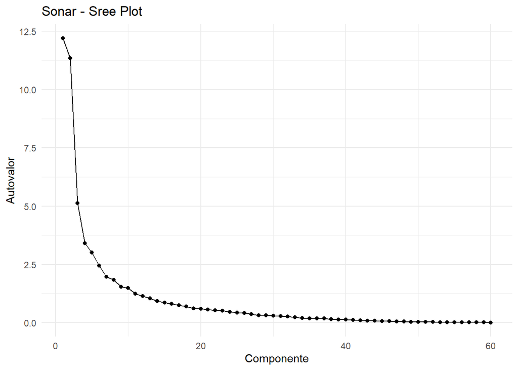

```r
qplot(y = ev2, x = seq_along(ev2), geom = c("line","point")) +
  labs(x = "Componente", y = "Autovalor", title = "Sonar - Sree Plot") +
  theme_minimal()
```

3. Faça um gráfico **CP1 vs CP2** com pontos coloridos por `y`. Comente se há **separação** entre M (mine) e R (rock).

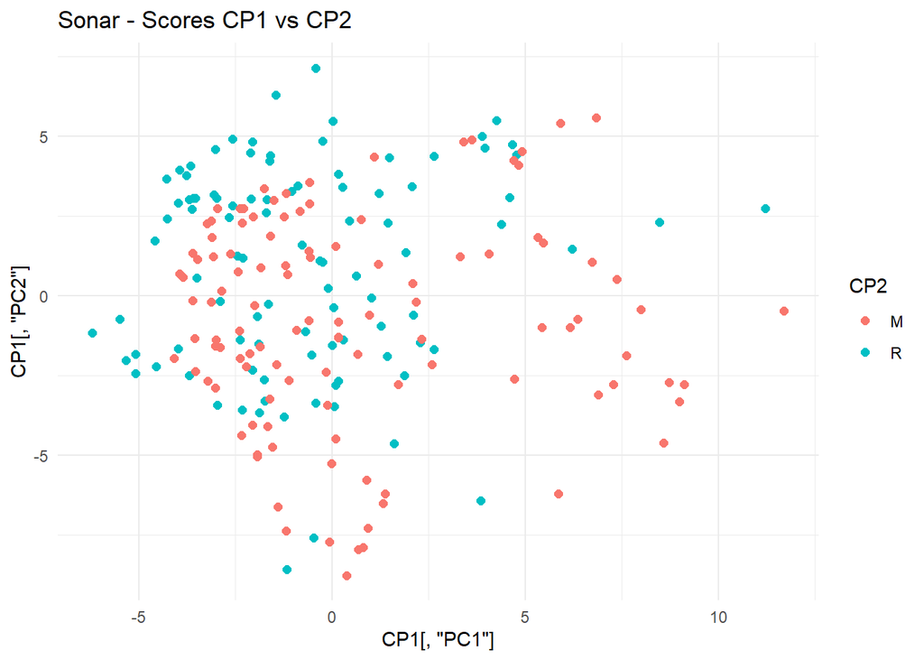

```r
sc2 <- tibble(pc_sonar$x[,1:2]) %>%
  mutate(Class = y_sonar)
colnames(sc2)[1:2] <- c("CP1","CP2")

ggplot(sc2, aes(x = CP1[,"PC1"], y = CP1[,"PC2"], color = CP2)) +
  geom_point(size = 2) +
  labs(title = "Sonar - Scores CP1 vs CP2") +
  theme_minimal()
```

> O gráfico de dispersão (Scores plot) mostra como os sinais de sonar se distribuem no espaço de variância reduzida. Embora a variável de classe (y) não tenha sido usada na construção da ACP (método não supervisionado), observamos se a variância natural dos dados coincide com as classes “Mine” (M) e “Rock” (R).
4. Mostre um **biplot** (atenção à escala visual). Quais as **5 variáveis** com maior |loading| em CP1 e CP2?

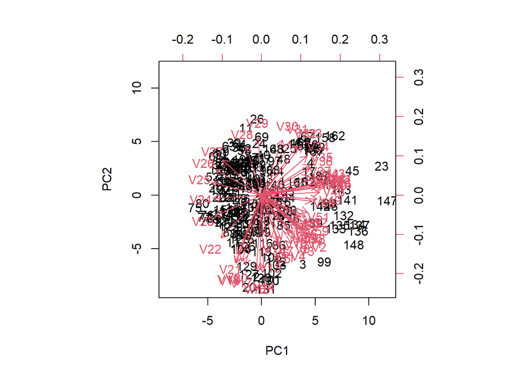

```r
biplot(pc_sonar, scale = 0)
```

```r
load2 <- pc_sonar$rotation
Top5_CP1 <- tibble(var = colnames(Sonar)[1:60][order(abs(load2[,1]), decreasing = TRUE)[1:5]],
                   loading = load2[order(abs(load2[,1]), decreasing = TRUE)[1:5],1])
Top5_CP2 <- tibble(var = colnames(Sonar)[1:60][order(abs(load2[,2]), decreasing = TRUE)[1:5]],
                   loading = load2[order(abs(load2[,2]), decreasing = TRUE)[1:5],2])

list(Top5_CP1 = Top5_CP1,
     Top5_CP2 = Top5_CP2)
```

```
## $Top5_CP1
## # A tibble: 5 × 2
##   var   loading
##   <chr>   <dbl>
## 1 V41     0.202
## 2 V45     0.201
## 3 V46     0.199
## 4 V42     0.198
## 5 V39     0.189
##
## $Top5_CP2
## # A tibble: 5 × 2
##   var   loading
##   <chr>   <dbl>
## 1 V16    -0.238
## 2 V15    -0.238
## 3 V14    -0.232
## 4 V17    -0.222
## 5 V19    -0.217
```

# Exercício 3 — Espectroscopia NIR (*yarn*; p ≈ 268 comprimentos de onda)

**Dados**: `pls::yarn`. Tem espectros NIR (muitas variáveis) e respostas químicas (ex.: `density`). Use **apenas** os **espectros** para ACP.

1. Carregue `pls` e examine `yarn`. Construa a matriz `X <- scale(yarn$NIR)` com padronização por coluna.

```r
X_yarn <- scale(yarn$NIR)
```

2. Aplique ACP a `X`. Reporte **valores próprios**, **PVE** e **PVE acumulada**. Produza os gráficos correspondentes.

```r
pc_yarn <- prcomp(X_yarn, center = FALSE)
ev3  <- pc_yarn$sdev^2
pve3 <- ev3 / sum(ev3)
cpve3 <- cumsum(pve3)

head(tibble(
  CP = 1:10,
  PVE = pve3[1:10],
  PVE_ACUM = cpve3[1:10]
))
```

```
## # A tibble: 6 × 3
##      CP     PVE PVE_ACUM
##   <int>   <dbl>    <dbl>
## 1     1 0.511      0.511
## 2     2 0.309      0.820
## 3     3 0.165      0.985
## 4     4 0.00987    0.995
## 5     5 0.00224    0.997
## 6     6 0.00127    0.998
```

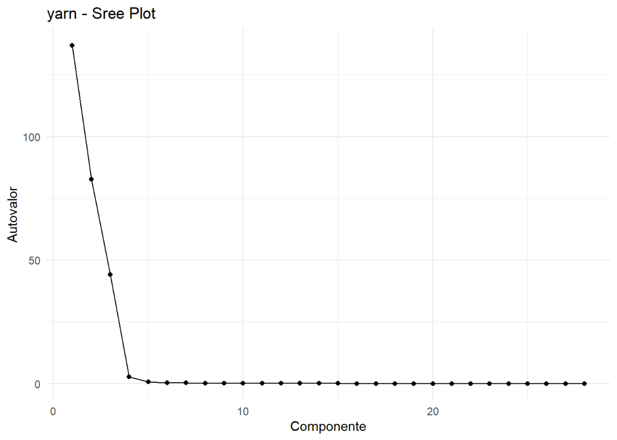

```r
qplot(y = ev3, x = seq_along(ev3), geom = c("line", "point")) +
  labs(x = "Componente", y = "Autovalor", title = "yarn - Sree Plot") +
  theme_minimal()
```

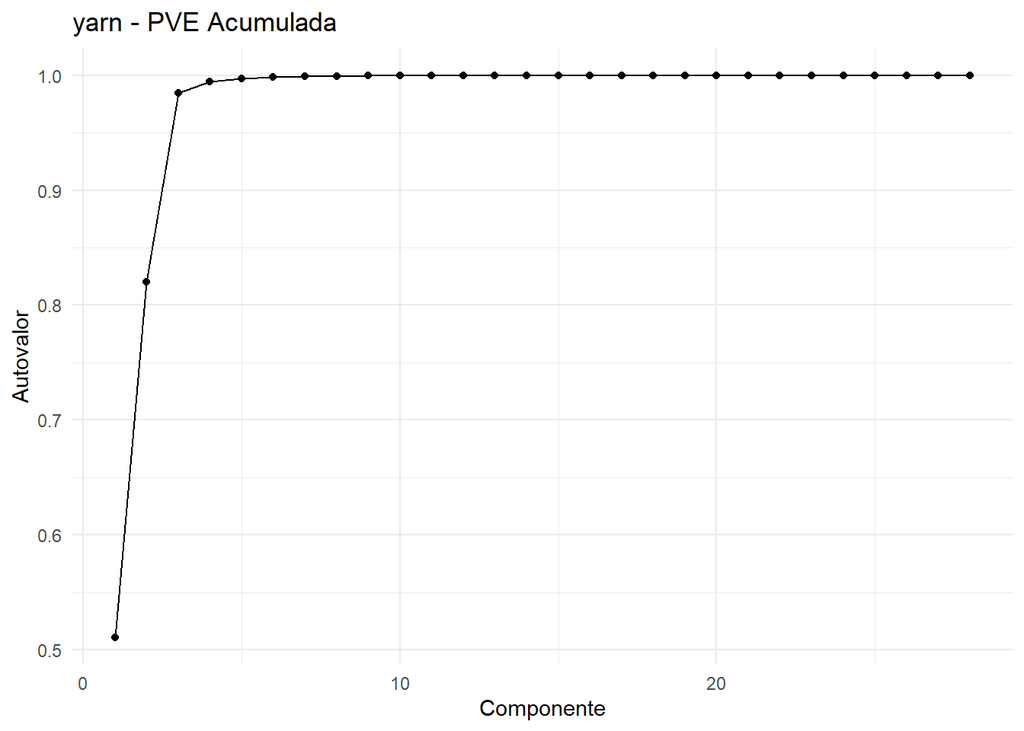

```r
qplot(y = cpve3, x = seq_along(cpve3), geom = c("line", "point")) +
  labs(x = "Componente", y = "Autovalor", title = "yarn - PVE Acumulada") +
  theme_minimal()
```

3. Faça **scores plots** (CP1 vs CP2, e CP2 vs CP3). Procure padrões (e.g., batches/lotes se disponíveis).

```r
sc3 <- as_tibble(pc_yarn$x[,1:3])
colnames(sc3) <- c("CP1","CP2","CP3")

g1 <- ggplot(sc3, aes(CP1, CP2)) +
  geom_point(size  = 1) +
  labs(title = "yarn - Scores CP1 vs CP2") +
  theme_minimal()

g2 <- ggplot(sc3, aes(CP2, CP3)) +
  geom_point(size  = 1) +
  labs(title = "yarn - Scores CP2 vs CP3") +
  theme_minimal()
```

[output not shown]

> Em dados espectrais (como NIR), os gráficos de scores raramente mostram nuvens de pontos aleatórias. Frequentemente, observa-se:

> **Agrupamentos**: Se existirem lotes de produção distintos ou tipos de fio diferentes, estes podem aparecer como clusters separados.

> **Tendências**: Muitas vezes vê-se uma forma contínua ou parabólica (efeito de arco), o que sugere que a variação nas propriedades químicas é contínua e não discreta.
4. Identifique **intervalos de onda** com maiores contribuições (|loadings| altos) para CP1 e CP2. Discuta possível interpretação.

```r
load3 <- pc_yarn$rotation
idx1 <- order(abs(load3[,1]), decreasing = TRUE)[1:15]
idx2 <- order(abs(load3[,2]), decreasing = TRUE)[1:15]
TopBand_CP1 <- tibble(indice_onda = idx1, loading = load3[idx1,1])
TopBand_CP2 <- tibble(indice_onda = idx2, loading = load3[idx2,2])

list(TopBand_CP1 = TopBand_CP1,
     TopBand_CP2 = TopBand_CP2)
```

```
## $TopBand_CP1
## # A tibble: 15 × 2
##    indice_onda loading
##          <int>   <dbl>
##  1          71 -0.0842
##  2          72 -0.0835
##  3          70 -0.0834
##  4         146 -0.0833
##  5         145 -0.0833
##  6          52  0.0832
##  7          73 -0.0830
##  8         112 -0.0830
##  9         114 -0.0830
## 10         111 -0.0830
## 11         113 -0.0830
```

[output cut: 24 more lines]

> Na espectroscopia NIR, os loadings podem ser interpretados quase como um “espectro de pesos”.

> Os intervalos de onda com maiores loadings na CP1 correspondem geralmente às regiões do espectro onde a variabilidade global é maior. Em muitos casos de sólidos/pós, a CP1 captura fenómenos físicos como o espalhamento de luz (light scattering) causado pelo tamanho de partícula, o que afeta todo o espectro (mudança de baseline).

> A CP2 (e seguintes) tende a corrigir esses efeitos físicos e focar-se nas características químicas, onde os loadings altos correspondem aos picos de absorção de grupos funcionais específicos (como ligações C-H ou O-H).